# p8105_hw3_yq2279

Qi Yuchen

2019/10/10

# Problem 1

- description of the dataset

```r
library(p8105.datasets)
data("instacart")

# Display the structure of the data
str(instacart)
```

```
## Classes 'tbl_df', 'tbl' and 'data.frame':    1384617 obs. of  15 variables:
##  $ order_id              : int  1 1 1 1 1 1 1 1 36 36 ...
##  $ product_id            : int  49302 11109 10246 49683 43633 13176 47209 22035 39612 19660 ...
##  $ add_to_cart_order     : int  1 2 3 4 5 6 7 8 1 2 ...
##  $ reordered             : int  1 1 0 0 1 0 0 1 0 1 ...
##  $ user_id               : int  112108 112108 112108 112108 112108 112108 112108 112108 79431 79431 ...
##  $ eval_set              : chr  "train" "train" "train" "train" ...
##  $ order_number          : int  4 4 4 4 4 4 4 4 23 23 ...
##  $ order_dow             : int  4 4 4 4 4 4 4 4 6 6 ...
##  $ order_hour_of_day     : int  10 10 10 10 10 10 10 10 18 18 ...
##  $ days_since_prior_order: int  9 9 9 9 9 9 9 9 30 30 ...
##  $ product_name          : chr  "Bulgarian Yogurt" "Organic 4% Milk Fat Whole Milk Cottage Cheese" "Organic Celery Hearts" "Cucumber Kirby" ...
##  $ aisle_id              : int  120 108 83 83 95 24 24 21 2 115 ...
##  $ department_id         : int  16 16 4 4 15 4 4 16 16 7 ...
##  $ aisle                 : chr  "yogurt" "other creams cheeses" "fresh vegetables" "fresh vegetables" ...
##  $ department            : chr  "dairy eggs" "dairy eggs" "produce" "produce" ...
##  - attr(*, "spec")=
##   .. cols(
##   ..   order_id = col_integer(),
##   ..   product_id = col_integer(),
##   ..   add_to_cart_order = col_integer(),
##   ..   reordered = col_integer(),
##   ..   user_id = col_integer(),
##   ..   eval_set = col_character(),
##   ..   order_number = col_integer(),
##   ..   order_dow = col_integer(),
##   ..   order_hour_of_day = col_integer(),
##   ..   days_since_prior_order = col_integer(),
##   ..   product_name = col_character(),
##   ..   aisle_id = col_integer(),
##   ..   department_id = col_integer(),
##   ..   aisle = col_character(),
##   ..   department = col_character()
##   .. )
```

- How many aisles are there, and which aisles are the most items ordered from?

```r
# number of aisles
summarise(instacart, n_aisles = n_distinct(aisle_id)) %>%
  knitr::kable()
```

| n_aisles |
| --- |
| 134 |

```r
# aisles that the most items are ordered from
instacart %>%
  group_by(aisle) %>%
  summarize(n_obs_aisle = n()) %>%
  filter(min_rank(desc(n_obs_aisle)) < 4) %>% # here we show the top 3
  arrange(desc(n_obs_aisle)) %>%
  knitr::kable()
```

| aisle | n_obs_aisle |
| --- | --- |
| fresh vegetables | 150609 |
| fresh fruits | 150473 |
| packaged vegetables fruits | 78493 |

There are 134 aisles, and the aisle that the most items are ordered from is fresh vegetables, followed by fresh fruits and packaged vegetables fruits.

- Make a plot that shows the number of items ordered in each aisle, limiting this to aisles with more than 10000 items ordered. Arrange aisles sensibly, and organize your plot so others can read it.

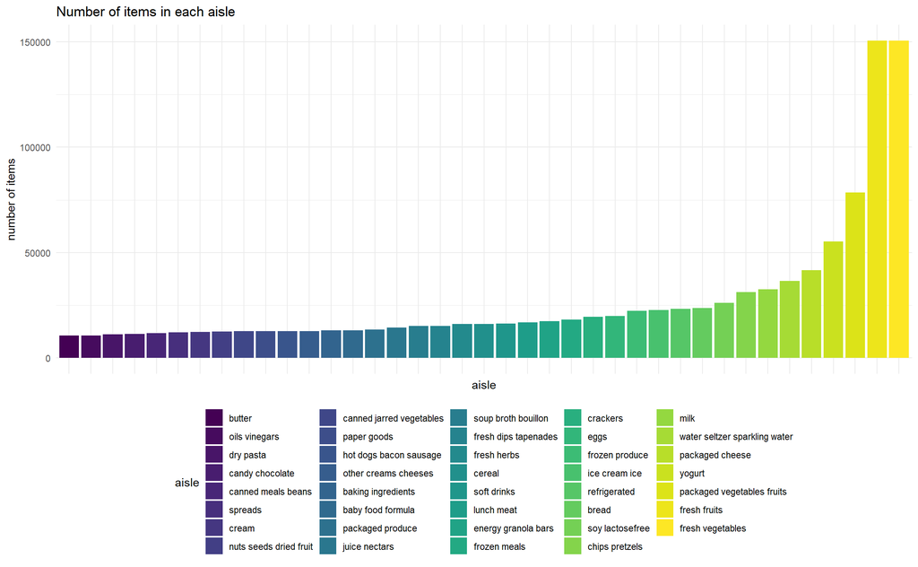

```r
instacart %>%
  group_by(aisle) %>%
  summarize(n_obs_aisle = n()) %>%
  filter(n_obs_aisle > 10000) %>%
  mutate(aisle = forcats::fct_reorder(aisle, n_obs_aisle)) %>%
  ggplot(aes(x = aisle, y = n_obs_aisle, fill = aisle)) +
  geom_bar(stat = "identity") +
  labs(
    title = "Number of items in each aisle",
    x = "aisle",
    y = "number of items"
  ) +
  theme(axis.text.x=element_blank())
```

- Make a table showing the three most popular items in each of the aisles “baking ingredients”, “dog food care”, and “packaged vegetables fruits”. Include the number of times each item is ordered in your table.

```r
instacart %>%
  filter(aisle == "baking ingredients" | aisle == "dog food care" | aisle == "packaged vegetables fruits") %>%
  group_by(aisle, product_name) %>%
  summarize(n_product = n()) %>%
  filter(min_rank(desc(n_product)) < 4) %>%
  knitr::kable()
```

| aisle | product_name | n_product |
| --- | --- | --- |
| baking ingredients | Cane Sugar | 336 |
| baking ingredients | Light Brown Sugar | 499 |
| baking ingredients | Pure Baking Soda | 387 |
| dog food care | Organix Chicken & Brown Rice Recipe | 28 |
| dog food care | Small Dog Biscuits | 26 |
| dog food care | Snack Sticks Chicken & Rice Recipe Dog Treats | 30 |
| packaged vegetables fruits | Organic Baby Spinach | 9784 |
| packaged vegetables fruits | Organic Blueberries | 4966 |
| packaged vegetables fruits | Organic Raspberries | 5546 |

- Make a table showing the mean hour of the day at which Pink Lady Apples and Coffee Ice Cream are ordered on each day of the week; format this table for human readers (i.e. produce a 2 x 7 table).

```r
instacart %>%
  filter(product_name == "Pink Lady Apples" | product_name == "Coffee Ice Cream") %>%
  group_by(product_name, order_dow) %>%
  summarize(mean_hour = mean(order_hour_of_day)) %>%
  pivot_wider(
    names_from = order_dow,
    values_from = mean_hour
  ) %>%
  rename(Sunday = "0", Monday = "1", Tuesday = "2", Wednesday = "3", Thursday = "4", Friday = "5", Saturday = "6") %>%
  knitr::kable(digits = 1)
```

| product_name | Sunday | Monday | Tuesday | Wednesday | Thursday | Friday | Saturday |
| --- | --- | --- | --- | --- | --- | --- | --- |
| Coffee Ice Cream | 13.8 | 14.3 | 15.4 | 15.3 | 15.2 | 12.3 | 13.8 |
| Pink Lady Apples | 13.4 | 11.4 | 11.7 | 14.2 | 11.6 | 12.8 | 11.9 |